# Fault surfaces v1 from catalog v5.1

2026-11-25 (revised after review the same day). Plane-based fault surfaces refitted on catalog v5.1 (NonLinLoc in the 3D model v0.3.1, re-timed picks), compared surface by surface with v0 (catalog v4). Code: `workflow/07_faults/v1_*.py` on branch analysis/v51-faults. Private working product.

**Status.** These products rest on catalog v5.1, which will be superseded. The PI adopted velocity model v0.4.0 (v0.3.1 re-inverted with the re-timed picks, D-B082); v0.4.1 (surface floor in the inversion, D-B083) is being built; catalog v6.0 (D-B079, NonLinLoc with SSST station terms) will replace v5.1, and the fault surfaces will be redone on v6.0. Waveform review reports for four v5.1 location problems are in `/wd1/mdenolle_data/catalog_v5/v5.1_review/index.html` (P1 Mount St Helens deep events, P2 Brookings 2012, P3 events with ComCat moment tensors, P4 deep-pass and far-only events); the surfaces and events they touch are flagged here.

## Summary

- **142 surfaces** (99 steep, dip ≥ 45°) from 101,296 well-constrained events (v0: 141 surfaces from 76,281 events). 64,272 events (63% of the fit set) are fit members of a surface (v0: 53,291, 70%).
- **Every located event** (171,719; 623 rows without a hypocentre left out) has an assignment: 64,272 fit members; 12,651 'assigned' (compatible with exactly one surface: within twice their combined uncertainty and within 10 km; this is compatibility, not location on the surface); 26,257 compatible with two or more surfaces (ambiguous); 37,468 compatible with no surface in the fitted regions; 26,874 at Axial Seamount, which was not fitted (left out as in v0), so they are neither on nor off a surface; 3,313 non-earthquakes (event_flag); 884 weekday-daytime members of surfaces removed for their timing (likely blasts). Fractions of events on or off faults must leave Axial out.
- **'assigned' is loose.** Of the 12,651 assigned events, 45% are tier D, 4,899 lie more than 5 km from the surface (median 4.0 km, against 0.71 km for fit members), 831 are floor_limited and 37 far_only (far-only events moved from near the surface in v4 to 44-64 km in v5.1; v5.1 review P4). The column `on_surface_strict` keeps fit members plus assigned tier A-C events within 2 km without floor_limited, far_only or deep_pass: 65,709 events.
- **Against v0** (by shared fit members): matched 50, new 39, split 23, split and merged 20, merged 10 among the v1 surfaces; of the 141 v0 surfaces: matched 50, merged 25, lost 23, split and merged 20, dispersed 13, split 10.
- **Literature:** 15 v1 surfaces carry a v0 match unchanged, 88 carry one marked for re-check (split, merged or moved), and 39 are new and need a literature check (`fault_surfaces_v1_literature_todo.csv`).
- **Uncertainty: the surfaces depend on the detection run.** sigma_total (median 0.59 km, 10th-90th percentile 0.23-1.07 km) and the strike/dip intervals hold for a fixed set of members only. The detection itself is much less certain. Over the four detection reruns of v0 (seeds, tolerance), the range of strike of the best-matching plane has a median of 103° for the 84 unstable surfaces and 6.5° for the 42 stable ones (non-strand surfaces matched in at least one rerun; the 12 strands are not rerun, and v1_MT031, v1_ON025, v1_WA002, v1_WA004 match no plane in any rerun). In the verifier's reruns, of the 130 non-strand surfaces, 38 are recovered (Jaccard ≥ 0.5) on a random 80 % of the fit set (27/42 of the 'stable' ones), 12 after moving every event once by its own catalog error (9/42 'stable'), and 10 of 116 on tiers A-B only; 9 pass both the subsample and the perturbation tests (v1_MT001, v1_ON014, v1_ON016, v1_ON021, v1_ON024, v1_OR001, v1_OR002, v1_PU006, v1_WA001). Do not use 0.59 km as the position uncertainty of a surface that fails these tests (columns `recovery_*`, `strike_settings_range_width`, flags).

**Findings to read first**

- **Most surfaces are not robust at the detection level.** The per-surface sigmas are conditional on the member set. Rerunning the detection on a random 80 % of the fit set recovers 38 of the 130 non-strand surfaces (Jaccard ≥ 0.5); moving every event once by its own catalog error recovers 12; tiers A-B alone recover 10 of 116. Only 9 pass both the subsample and the perturbation tests (v1_MT001, v1_ON014, v1_ON016, v1_ON021, v1_ON024, v1_OR001, v1_OR002, v1_PU006, v1_WA001), and 3 pass all three. The perturbation test is pessimistic, because tier B and C errors exceed the scatter. Over the builder's four reruns the strike range of the 84 unstable surfaces has a median of 103° (6.5° for the 42 stable ones; non-strand surfaces matched in at least one rerun; the 12 strands are not rerun, and v1_MT031, v1_ON025, v1_WA002, v1_WA004 match no plane in any rerun). Use a surface's geometry only where its `recovery_tests` and `stable` columns support it. There is no null test yet of how many 30-event 'planes' a catalog of the same density without faults would give.
- **Fewer events on a fault than v0, for a stated reason.** 142 surfaces hold 64,272 fit members. The first v1 run, with the v0 code unchanged, found 192 planes, 75,409 of 101,296 events (74 %), but 26 of its planes ended flatter than 30° after reassignment, as 24 of v0's 141 did. With the dip rule applied in every reassignment pass, flat clouds no longer pass as faults; the share on a fault drops most in Puget (v0 61 %, v1 34 %) and onshore, where v0 kept low-dip layers (PU001, PU002, ON002).
- **Matched surfaces moved with their events.** 50 v0 surfaces have one v1 counterpart. Their centroids moved a median 5.9 km horizontally and +2.3 km in depth, close to the median v4 → v5.1 depth shift of their events (+2.1 km). Strike changed by a median 23° (normals 26° apart); 17 kept their strike within 10° and 16 changed strike by more than 45° (14 have normals more than 45° apart). The other v0 surfaces: 25 merged, 10 split, 20 in mixed groups, 13 dispersed over several v1 surfaces, 23 lost; 39 v1 surfaces are new.
- **Blanco depths moved down; rectangles reach 30-50 km.** The events of the v0 Blanco Ridge strand (BL003a, 3,440 events) went from a median 9.2 km (v4) to 16.5 km (v5.1). Against the Lange et al. (2026) OBS catalog, v5.1 tier A-C Blanco Ridge events are a median 2.9 km deeper with a 90th percentile of +13 km, Gorda Depression +5.6 km (+16.6 km) (catalog paired_v5.1.md). This deep tail sets the bottom of the Blanco rectangles. 4 Blanco surfaces are centred below 20 km (v1_BL009, v1_BL012, v1_BL015, v1_BL016), and one deep surface under the Cascadia Depression with only 18 depth-ok events was removed as an artefact, as v0 did for three.
- **The Cascadia Depression N-S faults are not recovered as N-S planes.** The events of v0 BL005, BL008 and BL012 (N-S normal faults, high-confidence literature match) keep their N-S map elongation in v5.1 (azimuths 10°, 177°, 4°). The v1 detection first fitted a plane striking 121° and dipping 68° (2,357 events, 64 km long) through the dense cluster and on to the western Blanco Ridge (v1_BL004), then split the rest (BL005: v1_BL004 36%, v1_BL006 25%, v1_BL012 6%; BL008: v1_BL004 47%, v1_BL006 24%, v1_BL012 5%; BL012: v1_BL004 29%, v1_BL010 24%, v1_BL006 13%). This comes from the detection order, not from the relocation. A fit restricted to the Cascadia Depression is needed before v1 is used there.
- **Deep events under Mount St. Helens are probably a recurring non-earthquake signal.** Surface v1x_06 (39 events at 60 km under the volcano) was removed for its timing (64% weekday daytime). In the Mount St. Helens box, 331 of 7,471 located events are deeper than 30 km (30-118 km; tiers A 1, B 3, C 118, D 209; median sig_z 17 km although stations are a few km away), and 22 of them occur on Wednesdays between 19:14 and 19:20 UTC (on Tuesdays at that time: 0). The waveform review (v5.1 review P1) found that the analog UW channels HSR, EDM and STD carry a weekly artificial signal on Wednesdays 19:14-19:21 UTC from 2011-05 to 2013-08; the deep events are 96 % UW P picks, 80 % have all P picks within 0.5 s and 73 % have no S pick. They are likely false events, pending human review. Kept surface v1_ON028 (42 events, rectangle at 22-37 km under the volcano) holds part of the same population and is flagged; the 331 deep events carry a `catalog_note` in the assignment file. A catalog problem, not a fault.
- **The 2012 Brookings swarm is now at about 52 km.** v1_GO022 (39 events, 33 in 2012; v0 GO020, a candidate new structure at about 12 km) lies at 42-65 km in v5.1, against a median 20 km in v4; depth_quality is ok for 100% of its events, median sig_z 7 km, nearest station 45 km. Slab2 puts the slab top at a median 10 km under its events. The waveform review (v5.1 review P2) explains the depth: predicted S-P is not monotonic with depth in the v5.1 grids, so about 7-9 km and about 56 km both fit the distant stations, and NonLinLoc took the deep one. The surface and its events are flagged; its depth is not usable.
- **Endeavour-Explorer surfaces sit at 30-60 km** (5 surfaces) on events whose depths the catalog marks as unconstrained (ridge regions). Their map traces can be used; their depths and dips cannot.
- **Catalog errors and scatter.** Members were selected within the detection tolerance of their plane, so their residuals are truncated and the expected median |residual|/error is below 0.67: 0.67, 0.60 and 0.42 for tiers A, B and C. Observed: 0.77, 0.49 and 0.30. Tier A scatters about 15 % more than its errors allow: either the tier A errors are too small or the fault zones have a width. Tier B and C errors are larger than the scatter, by less than a comparison with 0.67 suggests. The RMS residual is 1.1-1.2 km for every tier, close to what the selection tolerance allows (about 2.3 km for vertical faults), so the zone widths are set by the method more than by the locations.
- **Surfaces whose members moved more than 10 km in depth from v4 to v5.1 are flagged** (17 surfaces, on the median shift of all members or of the depth_quality ok members). In 4 of them at least half of the events are depth_quality ok and those events themselves moved more than 10 km, where the catalog gives no other warning (median shift of the depth-ok members): v1_GO022 +30.6 km, v1_ON017 +15.0 km, v1_GO004 +14.8 km, v1_GO019 +13.2 km. v1_GO020 (63% depth-ok, +12.1 km for all members), v1_GO023 (65% depth-ok, +17.3 km for all members) are flagged on all members only: their depth-ok members moved a median +7.4, +8.9 km. The v5.1 events with ComCat moment tensors are a median 13.7 km deeper than ComCat (v5.1 review P3), so these depths are not confirmed.
- **Timing.** Of the members of the 9 surfaces removed for their timing, only the weekday-daytime ones (884) are marked as likely non-earthquakes; the other 253 are assigned like any event (column `removed_surface`). Kept surfaces with at least twice the fit-set weekday-daytime rate are flagged: v1_MT031 (53%, binomial p 0.0003), v1_ON030 (53%, binomial p 0.0002). 4 Blanco surfaces have a small but significant excess (28%-31% against the fit-set rate, binomial p below 0.05/152 because they are large), too small to point to blasts.

## Data and event selection

Fit set (PI choice of 2026-11-25): tiers A-C located by NonLinLoc, without floor_limited, far_only and deep_pass events, without ComCat explosions, quarry blasts and other non-earthquakes and without the Texada quarry_blast_likely events. Axial Seamount stays out as in v0 (published fault maps there are better). Rows are removed by the first rule that applies:

| Rule | Events |
| --- | --- |
| no hypocentre | 623 |
| not an earthquake (event_flag) | 3313 |
| tier D or U | 42671 |
| not located by NonLinLoc here | 0 |
| floor_limited | 3600 |
| far_only | 271 |
| deep_pass | 83 |
| Axial Seamount (left out, as in v0) | 20485 |
| used for the fit | 101296 |

Per-event error: sigma_h = sqrt((h_min² + h_max²)/2) / 1.515 (68 % semi-axes to one sigma, the convention of the tomography code; the catalog has no ellipse azimuth) and sigma_z = sig_z. Fit-set medians: sigma_h 1.35 km, sigma_z 3.59 km; by tier A 0.71/1.17 km, B 1.19/2.37 km, C 1.90/5.47 km. Depths are km below sea level.

## Method

1. **Detection**: the v0 method and parameters (`fault_surfaces_planes.py`): sequential local RANSAC with growth, tolerance 1.5 × sqrt((1.5 km |n_h|)² + (3 km n_z)²), ≥ 30 events, planarity ≤ 0.5, dip ≥ 30°, k-planes reassignment, merging. One change: the dip rule is also applied after every reassignment pass (in v0, 24 of the 141 surfaces ended flatter than 30° after reassignment).
2. **Blanco strands** (rule of `split_strands.py`, now automatic): steep Blanco planes within 35° of plate motion and mostly outside the Cascadia Depression box are re-searched as map-view strands in the three v0 pools (west, Blanco Ridge, Gorda Depression). Overlapping parallel strands stay apart only if Ashman's D > 2 overall and in every year where both have ≥ 15 events; pairs whose depth offset would need a single fault dipping ≥ 60° are merged (offset follows depth, the reason v0 merged its two 'deeper band' strands).
3. **Rectangles** as v0 (2-98 % extent along strike and dip + 0.5 km, plane or gentle quadratic by BIC, 1 km mesh).
4. **Uncertainty per surface**: bootstrap of the members (100 draws), location Monte Carlo moving every member by its own catalog error (100 draws; v0 used nominal 1.5/1.5/3 km), model choice, combined; strike/dip intervals from each; centroid spread; stability over the four detection reruns of v0 (Jaccard overlap). These intervals are conditional on the member set. The spread of the detection itself is given separately: strike/dip range of the best-matching plane over the four reruns, and recovery (Jaccard ≥ 0.5) in three detection reruns made by the verifier of this piece (80 % subsample, every event moved once by its own error, tiers A-B only; `work/verifier_reruns/`).
5. **Screening**: surfaces with ≥ 60 % of their events on weekdays 08-17 local time are removed (quarry blasts or other non-earthquake signals; catalog average 28 %); Blanco surfaces centred deeper than 25 km with fewer than 30 depth-ok events are removed as deep artefacts (v0 removed three such surfaces after its literature check); a final dip < 30° would also remove a surface (none left after the dip rule in detection). Of the members of a surface removed for its timing, only those on weekdays 08-17 local time are marked as likely non-earthquakes; the others are assigned like any event (column `removed_surface` keeps the link). Kept surfaces with at least twice the fit-set weekday-daytime rate are flagged.
6. **Assignment of every located event**: distance d to the surface (offset normal to the fitted surface at the nearest point of the rectangle, plus the in-plane distance outside it); z = d / sqrt(s_e² + s_s² + W²) with s_e the event's error along that direction, s_s the surface's median sigma_total and W its zone width once the member errors are taken out. Compatible: z ≤ 2 and d ≤ 10 km. Assigned: exactly one compatible surface (compatibility, not location on it); ambiguous: two or more; none: no compatible surface; Axial Seamount events: not fitted. `on_surface_strict`: fit members and assigned tier A-C events within 2 km, without floor_limited, far_only or deep_pass.
7. **Comparison with v0**: v0 members (catalog v4 IDs, the same as v5.1 IDs) against v1 fit members. A v0 and a v1 surface are linked when they share ≥ 15 events and these are ≥ 50 % of the v0 surface's re-found events, or ≥ 50 % of the v1 surface's events that were on a v0 surface, or ≥ 30 % of both. Connected groups: matched (1-1), split (1-n), merged (n-1), split and merged, new, lost. Removed v1 surfaces take part in the links, so a v0 surface whose events now form a removed surface is reported as lost with that reason. Literature is carried unchanged only for matched surfaces whose normals are within 25°, centroids within 10 km horizontally and within 5 km in depth; every other carried match is marked for re-check.

## Maps

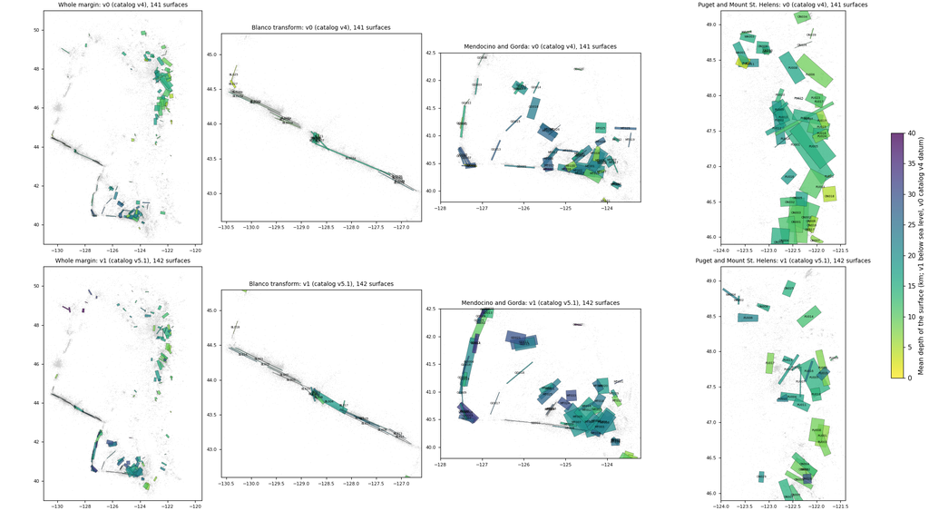

Rectangles of v0 (top, catalog v4) and v1 (bottom, catalog v5.1) over the located events of v5.1.

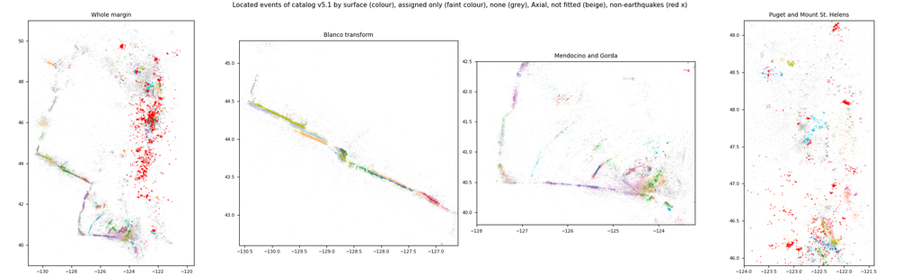

Assignment of the located v5.1 events.

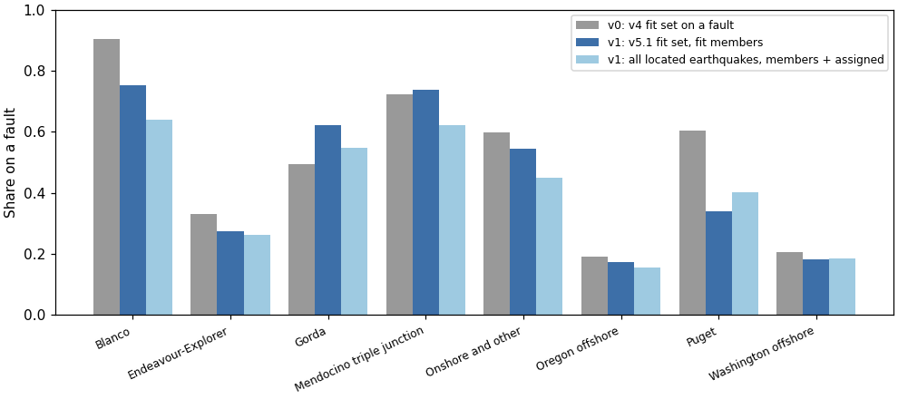

Share of events on a fault by region.

| region | located | earthquakes | not_fitted | fit_set | fit_members | frac_fit_set_on_a_fault | assigned_other | frac_earthquakes_on_a_fault | on_surface_strict | frac_earthquakes_on_surface_strict | ambiguous | none | non_earthquake_timing_screening |
| --- | --- | --- | --- | --- | --- | --- | --- | --- | --- | --- | --- | --- | --- |
| AX | 26874 | 26874 | 26874 | 0 | 0 |  | 0 |  | 0 |  | 0 | 0 | 0 |
| BL | 42728 | 42728 | 0 | 32508 | 24424 | 0.75 | 2945 | 0.64 | 25092 | 0.59 | 11797 | 3562 | 0 |
| EN | 2481 | 2481 | 0 | 1133 | 310 | 0.27 | 346 | 0.26 | 323 | 0.13 | 18 | 1807 | 0 |
| GO | 10255 | 10251 | 0 | 7327 | 4547 | 0.62 | 1069 | 0.55 | 4601 | 0.45 | 1975 | 2660 | 0 |
| MT | 38122 | 38122 | 0 | 27909 | 20605 | 0.74 | 3159 | 0.62 | 20929 | 0.55 | 8194 | 6164 | 0 |
| ON | 31736 | 29055 | 0 | 18837 | 10259 | 0.55 | 2848 | 0.45 | 10467 | 0.36 | 3602 | 11741 | 605 |
| OR | 1923 | 1721 | 0 | 734 | 128 | 0.17 | 139 | 0.15 | 132 | 0.08 | 1 | 1453 | 0 |
| PU | 14139 | 13734 | 0 | 10488 | 3572 | 0.34 | 1935 | 0.40 | 3712 | 0.27 | 630 | 7397 | 200 |
| WA | 3461 | 3440 | 0 | 2360 | 427 | 0.18 | 210 | 0.18 | 453 | 0.13 | 40 | 2684 | 79 |

## Comparison with v0

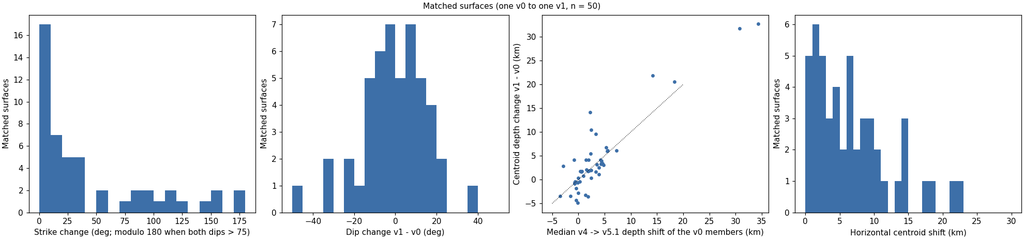

Matched surfaces: change of strike, dip, depth and position.

Matched pairs (n = 50): median strike change 23°, median |dip change| 10°, median centroid shift 5.9 km horizontally and +2.3 km in depth (the members' own median v4 → v5.1 depth shift: +2.1 km).

### Every v1 surface

| surface_id | region | n_events | lon | lat | depth_km | strike | strike_68 | dip | dip_68 | dip_depth_ok | length_km | width_km | sigma_total_median_km | frac_depth_ok | stable | strike_settings_range_width | recovery_tests | change_from_v0 | v0_surfaces | lit_status | flags |
| --- | --- | --- | --- | --- | --- | --- | --- | --- | --- | --- | --- | --- | --- | --- | --- | --- | --- | --- | --- | --- | --- |
| v1_BL001 | BL | 5180 | -129.8 | 44.3 | 10.7 | 296.1 | 116.1;116.2 | 89.6 | 89.5;89.7 | 88.4 | 83.6 | 25.2 | 0.10 | 0.57 | False |  |  | split and merged | BL004a;BL004b;BL006a;BL015a;BL018a | carried from v0 BL004b, BL004a, BL018a (split and merged), re-check | rectangle above the ground or seafloor at 34 mesh vertices (extrapolation); Blanco strand: dip near 90 deg and its narrow interval are set by the map-view band selection (half-width 1.5 km), not measu… |
| v1_BL002 | BL | 4369 | -129.6 | 44.2 | 10.7 | 116.3 | 116.3;116.4 | 89.6 | 89.5;89.7 | 89.8 | 121.4 | 29.6 | 0.15 | 0.54 | False |  |  | split and merged | BL004a;BL004b;BL006a;BL015a;BL018a | carried from v0 BL006a, BL004a, BL015a (split and merged), re-check | rectangle above the ground or seafloor at 39 mesh vertices (extrapolation); Blanco strand: dip near 90 deg and its narrow interval are set by the map-view band selection (half-width 1.5 km), not measu… |
| v1_BL003 | BL | 2369 | -129.2 | 44.0 | 10.1 | 113.1 | 113.1;113.2 | 89.9 | 89.7;90.0 | 89.5 | 63.0 | 23.8 | 0.12 | 0.70 | True |  |  | matched | BL001a | carried from v0 BL001a (matched: normals 2 deg apart, centroids 0 km apart horizontally and +3 km in depth) | Blanco strand: dip near 90 deg and its narrow interval are set by the map-view band selection (half-width 1.5 km), not measured |
| v1_BL004 | BL | 2357 | -128.6 | 43.8 | 10.4 | 120.9 | 120.8;120.9 | 68.5 | 68.3;68.7 | 66.1 | 63.9 | 30.0 | 0.38 | 0.51 | False | 166.9 | 0/3 | merged | BL008;BL021 | carried from v0 BL008, BL021 (merged), re-check | unstable under detection reruns (Jaccard < 0.5); not recovered in 3 of 3 verifier detection reruns (80 % subsample, error perturbation, tiers A-B only): sigma_total and the strike/dip intervals hold f… |
| v1_BL005 | BL | 2200 | -127.8 | 43.5 | 16.2 | 113.3 | 113.3;113.3 | 89.3 | 89.2;89.5 | 89.3 | 82.8 | 29.4 | 0.14 | 0.69 | True |  |  | split | BL003a | carried from v0 BL003a, re-check: BL003a split into v1_BL005, v1_BL009, v1_BL015, v1_BL017 | Blanco strand: dip near 90 deg and its narrow interval are set by the map-view band selection (half-width 1.5 km), not measured |
| v1_BL006 | BL | 1654 | -128.7 | 43.8 | 7.76 | 316.3 | 316.0;316.8 | 64.9 | 64.3;65.5 | 63.4 | 26.0 | 14.6 | 0.31 | 0.55 | False | 14.8 | 0/3 | matched | BL011b | carried from v0 BL011b, re-check: same events, geometry changed (normals 30 deg, centroids 1 km apart horizontally, -2 km in depth) | unstable under detection reruns (Jaccard < 0.5); not recovered in 3 of 3 verifier detection reruns (80 % subsample, error perturbation, tiers A-B only): sigma_total and the strike/dip intervals hold f… |
| v1_BL007 | BL | 1341 | -129.3 | 44.1 | 10.8 | 116.1 | 116.0;116.1 | 89.6 | 89.4;89.7 | 89.0 | 59.6 | 26.3 | 0.21 | 0.55 | False |  |  | matched | BL001b | carried from v0 BL001b (matched: normals 1 deg apart, centroids 1 km apart horizontally and +2 km in depth) | rectangle above the ground or seafloor at 2 mesh vertices (extrapolation); Blanco strand: dip near 90 deg and its narrow interval are set by the map-view band selection (half-width 1.5 km), not measur… |
| v1_BL008 | BL | 1039 | -127.3 | 43.3 | 15.9 | 116.6 | 116.5;116.6 | 89.0 | 88.9;89.2 | 88.7 | 102.5 | 39.6 | 0.23 | 0.45 | False |  |  | split and merged | BL014a;BL016a;BL016b;BL017a | carried from v0 BL014a, BL017a (split and merged), re-check | depth poorly constrained (45% depth_quality ok): dip and depth extent not reliable; rectangle above the ground or seafloor at 20 mesh vertices (extrapolation); Blanco strand: dip near 90 deg and its n… |
| v1_BL009 | BL | 877 | -127.8 | 43.5 | 23.1 | 112.9 | 112.8;112.9 | 88.3 | 88.2;88.4 | 89.8 | 70.3 | 39.0 | 0.15 | 0.32 | True |  |  | split | BL003a | carried from v0 BL003a, re-check: BL003a split into v1_BL005, v1_BL009, v1_BL015, v1_BL017 | depth poorly constrained (32% depth_quality ok): dip and depth extent not reliable; centroid deeper than 20 km, below published Blanco seismicity (10-14 km); Blanco strand: dip near 90 deg and its nar… |
| v1_BL010 | BL | 726 | -128.8 | 43.8 | 17.9 | 344.6 | 164.2;165.0 | 86.1 | 86.0;86.4 | 84.8 | 23.7 | 34.1 | 0.16 | 0.48 | False | 40.2 | 0/3 | matched | BL012 | carried from v0 BL012, re-check: same events, geometry changed (normals 25 deg, centroids 3 km apart horizontally, +3 km in depth) | depth poorly constrained (48% depth_quality ok): dip and depth extent not reliable; unstable under detection reruns (Jaccard < 0.5); not recovered in 3 of 3 verifier detection reruns (80 % subsample, … |
| v1_BL011 | BL | 532 | -127.1 | 43.2 | 16.0 | 302.4 | 122.2;122.5 | 89.6 | 89.5;89.8 | 89.0 | 44.0 | 45.3 | 0.30 | 0.59 | True |  |  | split and merged | BL014a;BL016a;BL016b;BL017a | carried from v0 BL016a, BL014a (split and merged), re-check | rectangle above the ground or seafloor at 13 mesh vertices (extrapolation); Blanco strand: dip near 90 deg and its narrow interval are set by the map-view band selection (half-width 1.5 km), not measu… |
| v1_BL012 | BL | 424 | -128.7 | 43.8 | 26.6 | 152.3 | 151.5;153.1 | 86.3 | 86.1;86.6 | 88.2 | 14.6 | 31.2 | 0.23 | 0.44 | False | 34.3 | 0/3 | new |  | new in v1: literature check needed | depth poorly constrained (44% depth_quality ok): dip and depth extent not reliable; centroid deeper than 20 km, below published Blanco seismicity (10-14 km); unstable under detection reruns (Jaccard <… |
| v1_BL013 | BL | 339 | -127.1 | 43.2 | 18.0 | 300.1 | 119.9;120.4 | 89.5 | 89.3;89.7 | 88.8 | 31.4 | 43.9 | 0.24 | 0.49 | True |  |  | split and merged | BL014a;BL016a;BL016b;BL017a | carried from v0 BL016a, BL016b (split and merged), re-check | depth poorly constrained (49% depth_quality ok): dip and depth extent not reliable; Blanco strand: dip near 90 deg and its narrow interval are set by the map-view band selection (half-width 1.5 km), n… |
| v1_BL014 | BL | 295 | -130.2 | 44.4 | 14.7 | 116.5 | 116.3;116.6 | 89.1 | 88.9;89.3 | 89.3 | 49.9 | 40.2 | 0.38 | 0.42 | True |  |  | split and merged | BL004a;BL004b;BL006a;BL015a;BL018a | carried from v0 BL015a (split and merged), re-check | depth poorly constrained (42% depth_quality ok): dip and depth extent not reliable; rectangle above the ground or seafloor at 32 mesh vertices (extrapolation); Blanco strand: dip near 90 deg and its n… |
| v1_BL015 | BL | 257 | -127.8 | 43.4 | 22.7 | 295.8 | 115.6;115.9 | 89.8 | 89.6;89.9 | 87.9 | 83.0 | 47.8 | 0.36 | 0.25 | True |  |  | split | BL003a | carried from v0 BL003a, re-check: BL003a split into v1_BL005, v1_BL009, v1_BL015, v1_BL017 | depth poorly constrained (25% depth_quality ok): dip and depth extent not reliable; centroid deeper than 20 km, below published Blanco seismicity (10-14 km); Blanco strand: dip near 90 deg and its nar… |
| v1_BL016 | BL | 227 | -128.7 | 43.8 | 25.9 | 343.0 | 162.3;163.6 | 88.1 | 87.6;88.3 | 87.2 | 14.7 | 21.9 | 0.30 | 0.42 | False | 59.0 | 0/3 | new |  | new in v1: literature check needed | depth poorly constrained (42% depth_quality ok): dip and depth extent not reliable; centroid deeper than 20 km, below published Blanco seismicity (10-14 km); unstable under detection reruns (Jaccard <… |
| v1_BL017 | BL | 97 | -128.2 | 43.6 | 11.7 | 10.7 | 9.8;11.7 | 85.5 | 84.8;86.4 | 86.0 | 15.7 | 18.3 | 0.52 | 0.52 | False | 9.10 | 0/3 | split | BL003a | carried from v0 BL003a, re-check: BL003a split into v1_BL005, v1_BL009, v1_BL015, v1_BL017 | unstable under detection reruns (Jaccard < 0.5); not recovered in 3 of 3 verifier detection reruns (80 % subsample, error perturbation, tiers A-B only): sigma_total and the strike/dip intervals hold f… |
| v1_BL018 | BL | 73 | -130.3 | 44.7 | 4.44 | 198.5 | 16.1;20.2 | 86.3 | 67.1;87.2 |  | 21.4 | 5.30 | 0.69 | 0.26 | False | 0.80 | 0/2 | matched | BL025 | carried from v0 BL025 (matched: normals 1 deg apart, centroids 6 km apart horizontally and +2 km in depth) | depth poorly constrained (26% depth_quality ok): dip and depth extent not reliable; rectangle above the ground or seafloor at 7 mesh vertices (extrapolation); unstable under detection reruns (Jaccard … |
| v1_BL019 | BL | 40 | -128.9 | 43.9 | 13.1 | 311.3 | 130.5;132.4 | 89.6 | 88.7;89.7 |  | 20.8 | 36.9 | 0.88 | 0.62 | False |  |  | new |  | new in v1: literature check needed | Blanco strand: dip near 90 deg and its narrow interval are set by the map-view band selection (half-width 1.5 km), not measured; unstable under detection reruns (Jaccard < 0.5) |
| v1_EN001 | EN | 94 | -129.4 | 48.9 | 45.4 | 120.7 | 120.2;121.6 | 78.0 | 76.3;78.8 |  | 37.4 | 22.6 | 0.55 | 0.00 | True | 13.5 | 1/3 | matched | EN002 | carried from v0 EN002, re-check: same events, geometry changed (normals 7 deg, centroids 7 km apart horizontally, +32 km in depth) | depth poorly constrained (0% depth_quality ok): dip and depth extent not reliable; centroid deeper than 25 km on unconstrained ridge-region depths; members moved a median +29.4 km in depth from catalo… |
| v1_EN002 | EN | 87 | -127.6 | 49.7 | 29.7 | 332.4 | 331.6;333.1 | 70.3 | 68.7;71.9 |  | 31.6 | 17.9 | 0.59 | 0.00 | True | 0.20 | 1/2 | matched | EN003 | carried from v0 EN003, re-check: same events, geometry changed (normals 15 deg, centroids 7 km apart horizontally, +20 km in depth) | depth poorly constrained (0% depth_quality ok): dip and depth extent not reliable; centroid deeper than 25 km on unconstrained ridge-region depths; members moved a median +18.1 km in depth from catalo… |
| v1_EN003 | EN | 56 | -128.1 | 48.7 | 60.3 | 185.6 | 182.3;188.0 | 47.6 | 43.3;51.6 |  | 21.9 | 15.6 | 0.79 | 0.00 | True | 60.9 | 1/3 | new |  | new in v1: literature check needed | depth poorly constrained (0% depth_quality ok): dip and depth extent not reliable; centroid deeper than 25 km on unconstrained ridge-region depths; members moved a median +41.9 km in depth from catalo… |
| v1_EN004 | EN | 34 | -127.9 | 49.2 | 45.7 | 293.1 | 109.4;115.7 | 85.6 | 84.0;87.2 |  | 15.4 | 21.9 | 1.01 | 0.00 | True | 11.3 | 0/2 | matched | EN004 | carried from v0 EN004, re-check: same events, geometry changed (normals 74 deg, centroids 2 km apart horizontally, +33 km in depth) | depth poorly constrained (0% depth_quality ok): dip and depth extent not reliable; centroid deeper than 25 km on unconstrained ridge-region depths; members moved a median +34.0 km in depth from catalo… |
| v1_EN005 | EN | 34 | -129.1 | 48.8 | 39.4 | 350.9 | 348.4;353.5 | 63.2 | 57.1;68.6 |  | 28.3 | 14.4 | 0.94 | 0.00 | False | 59.7 | 0/3 | new |  | new in v1: literature check needed | depth poorly constrained (0% depth_quality ok): dip and depth extent not reliable; centroid deeper than 25 km on unconstrained ridge-region depths; members moved a median +33.7 km in depth from catalo… |
| v1_GO001 | GO | 966 | -125.7 | 40.4 | 27.5 | 275.5 | 95.5;95.6 | 89.8 | 89.1;89.9 | 89.9 | 126.2 | 16.2 | 0.19 | 0.99 | False | 3.00 | 0/3 | merged | GO001;MT015;MT016;MT022 | carried from v0 GO001, MT015, MT022, MT016 (merged), re-check | unstable under detection reruns (Jaccard < 0.5); not recovered in 3 of 3 verifier detection reruns (80 % subsample, error perturbation, tiers A-B only): sigma_total and the strike/dip intervals hold f… |
| v1_GO002 | GO | 562 | -127.0 | 42.3 | 8.26 | 22.5 | 22.2;22.7 | 42.9 | 42.1;43.8 | 41.6 | 88.0 | 20.1 | 0.56 | 0.67 | True | 5.60 | 0/3 | split | GO008 | carried from v0 GO008, re-check: GO008 split into v1_GO002, v1_GO024 | rectangle above the ground or seafloor at 40 mesh vertices (extrapolation); not recovered in 3 of 3 verifier detection reruns (80 % subsample, error perturbation, tiers A-B only): sigma_total and the … |
| v1_GO003 | GO | 402 | -127.3 | 40.6 | 31.1 | 128.3 | 127.8;129.0 | 48.9 | 48.3;49.4 | 50.6 | 35.6 | 22.8 | 0.36 | 0.56 | False | 20.4 | 0/3 | new |  | new in v1: literature check needed | unstable under detection reruns (Jaccard < 0.5); not recovered in 3 of 3 verifier detection reruns (80 % subsample, error perturbation, tiers A-B only): sigma_total and the strike/dip intervals hold f… |
| v1_GO004 | GO | 363 | -127.3 | 41.5 | 19.8 | 12.4 | 12.1;12.7 | 51.9 | 50.8;52.9 | 46.7 | 97.6 | 24.7 | 0.46 | 0.50 | False | 165.1 | 0/3 | split and merged | GO002;GO016 | carried from v0 GO002 (split and merged), re-check | members moved a median +14.9 km in depth from catalog v4 to v5.1 (+14.8 km for the 50% with depth_quality ok): depth not confirmed (v5.1 events with ComCat moment tensors are a median 13.7 km deeper t… |
| v1_GO005 | GO | 311 | -127.4 | 40.7 | 26.5 | 153.5 | 153.2;153.7 | 79.3 | 78.6;80.2 | 76.7 | 37.6 | 18.0 | 0.25 | 0.21 | False | 3.20 | 0/3 | matched | GO005 | carried from v0 GO005 (matched: normals 3 deg apart, centroids 4 km apart horizontally and -1 km in depth) | depth poorly constrained (21% depth_quality ok): dip and depth extent not reliable; unstable under detection reruns (Jaccard < 0.5); not recovered in 3 of 3 verifier detection reruns (80 % subsample, … |
| v1_GO006 | GO | 282 | -127.3 | 40.6 | 32.6 | 132.7 | 132.3;133.2 | 48.5 | 47.6;49.1 | 52.9 | 47.4 | 21.7 | 0.41 | 0.34 | False | 17.1 | 0/3 | matched | GO007 | carried from v0 GO007, re-check: same events, geometry changed (normals 26 deg, centroids 6 km apart horizontally, +4 km in depth) | depth poorly constrained (34% depth_quality ok): dip and depth extent not reliable; unstable under detection reruns (Jaccard < 0.5); not recovered in 3 of 3 verifier detection reruns (80 % subsample, … |

[output cut: 112 more lines]

### Every v0 surface: what became of it

| v0_surface | change | v1_surfaces | v1_removed | v0_n_events | located_in_v51 | in_v1_fit_set | fit_members_of_kept_v1 | top_v1_surfaces | members_median_shift_z_km | v0_lit_class | note |
| --- | --- | --- | --- | --- | --- | --- | --- | --- | --- | --- | --- |
| BL005 | dispersed |  |  | 1022 | 1022 | 1018 | 790 | v1_BL004 36%, v1_BL006 25%, v1_BL012 6% | -0.00 | known structure | 100% of its events are in the v1 fit set; 77% are fit members of v1 surfaces, none holding enough of them for a link |
| BL007 | lost |  |  | 970 | 970 | 968 | 393 | v1_BL004 18%, v1_BL010 10%, v1_BL012 5% | 0.30 | known structure | 100% of its events are in the v1 fit set; 41% are fit members of v1 surfaces, none holding enough of them for a link |
| BL008 | merged | v1_BL004 |  | 910 | 910 | 906 | 729 | v1_BL004 47%, v1_BL006 24%, v1_BL012 5% | -1.50 | known structure |  |
| BL012 | matched | v1_BL010 |  | 668 | 668 | 664 | 497 | v1_BL004 29%, v1_BL010 24%, v1_BL006 13% | -2.90 | known structure |  |
| BL021 | merged | v1_BL004 |  | 122 | 122 | 121 | 85 | v1_BL004 66%, v1_BL012 3%, v1_BL006 1% | -0.60 | known structure |  |
| BL025 | matched | v1_BL018 |  | 68 | 68 | 65 | 30 | v1_BL018 44% | 2.00 | known structure |  |
| BL027 | lost |  |  | 42 | 42 | 41 | 0 |  | 1.80 | known structure | 98% of its events are in the v1 fit set; 0% are fit members of v1 surfaces, none holding enough of them for a link |
| EN001 | lost |  |  | 121 | 121 | 12 | 0 |  | -12.7 | known structure | 10% of its events are in the v1 fit set; 0% are fit members of v1 surfaces, none holding enough of them for a link |
| EN002 | matched | v1_EN001 |  | 73 | 73 | 73 | 56 | v1_EN001 70%, v1_EN005 7% | 30.8 | known structure |  |
| EN003 | matched | v1_EN002 |  | 46 | 46 | 45 | 38 | v1_EN002 83% | 18.3 | known structure |  |
| EN004 | matched | v1_EN004 |  | 39 | 39 | 38 | 20 | v1_EN004 51% | 34.3 | known structure |  |
| GO001 | merged | v1_GO001 |  | 282 | 282 | 280 | 241 | v1_GO001 85% | 4.90 | known structure |  |
| GO002 | split and merged | v1_GO004;v1_GO008;v1_GO009;v1_GO019 |  | 231 | 231 | 229 | 209 | v1_GO008 33%, v1_GO004 23%, v1_GO009 17% | 13.4 | known structure |  |
| GO003 | split | v1_GO012;v1_GO014 |  | 194 | 194 | 191 | 162 | v1_GO014 27%, v1_GO012 24%, v1_GO002 18% | 11.1 | known structure |  |
| GO004 | merged | v1_GO007 |  | 189 | 189 | 189 | 162 | v1_GO007 38%, v1_GO003 26%, v1_GO006 10% | 3.00 | known structure |  |
| GO005 | matched | v1_GO005 |  | 185 | 185 | 181 | 169 | v1_GO005 54%, v1_GO006 14%, v1_GO003 13% | -0.70 | known structure |  |
| GO006 | merged | v1_GO007 |  | 151 | 151 | 150 | 130 | v1_GO003 32%, v1_GO007 31%, v1_GO006 15% | 3.70 | known structure |  |
| GO007 | matched | v1_GO006 |  | 107 | 107 | 107 | 96 | v1_GO003 36%, v1_GO006 30%, v1_GO009 14% | -0.80 | duplicate |  |
| GO008 | split | v1_GO002;v1_GO024 |  | 99 | 99 | 90 | 81 | v1_GO002 41%, v1_GO024 17%, v1_GO013 10% | 4.60 | known structure |  |
| GO009 | matched | v1_GO010 |  | 76 | 76 | 75 | 73 | v1_GO010 62%, v1_GO003 20%, v1_GO005 8% | -0.10 | duplicate |  |
| GO010 | dispersed |  |  | 62 | 62 | 53 | 43 | v1_GO011 34%, v1_GO015 21%, v1_GO021 15% | 3.60 | known structure | 85% of its events are in the v1 fit set; 69% are fit members of v1 surfaces, none holding enough of them for a link |
| GO011 | matched | v1_GO011 |  | 54 | 54 | 54 | 49 | v1_GO011 57%, v1_GO021 22%, v1_GO015 11% | 7.30 | known structure |  |
| GO012 | matched | v1_GO016 |  | 53 | 53 | 52 | 41 | v1_GO016 47%, v1_GO004 15%, v1_GO008 15% | 14.2 | known structure |  |
| GO013 | matched | v1_GO017 |  | 48 | 48 | 47 | 44 | v1_GO017 92% | -3.50 | known structure |  |
| GO014 | dispersed |  |  | 47 | 47 | 47 | 26 | v1_GO015 30%, v1_GO011 26% | 7.30 | known structure | 100% of its events are in the v1 fit set; 55% are fit members of v1 surfaces, none holding enough of them for a link |
| GO015 | matched | v1_GO018 |  | 44 | 44 | 43 | 30 | v1_GO018 68% | -1.50 | known structure |  |
| GO016 | split and merged | v1_GO004;v1_GO008;v1_GO009;v1_GO019 |  | 40 | 40 | 38 | 36 | v1_GO008 45%, v1_GO009 25%, v1_GO004 18% | 15.0 | duplicate |  |
| GO017 | dispersed |  |  | 37 | 37 | 34 | 30 | v1_GO015 35%, v1_GO011 32%, v1_GO021 14% | 6.50 | known structure | 92% of its events are in the v1 fit set; 81% are fit members of v1 surfaces, none holding enough of them for a link |
| GO018 | lost |  |  | 37 | 37 | 37 | 8 | v1_GO018 22% | 2.70 | known structure | 100% of its events are in the v1 fit set; 22% are fit members of v1 surfaces, none holding enough of them for a link |
| GO019 | dispersed |  |  | 35 | 35 | 33 | 29 | v1_GO007 40%, v1_GO003 17%, v1_GO006 11% | 27.0 | duplicate | 94% of its events are in the v1 fit set; 83% are fit members of v1 surfaces, none holding enough of them for a link |

[output cut: 111 more lines]

### Lost v0 surfaces

| v0_surface | v0_n_events | v0_dip | v0_depth_km | in_v1_fit_set | fit_members_of_kept_v1 | top_v1_surfaces | v0_lit_class | v0_lit_match | note |
| --- | --- | --- | --- | --- | --- | --- | --- | --- | --- |
| BL007 | 970 | 86.6 | 12.9 | 968 | 393 | v1_BL004 18%, v1_BL010 10%, v1_BL012 5% | known structure | CAS internal structure joining the CAS N–S faults to the W tip of the BR (oblique composite) | 100% of its events are in the v1 fit set; 41% are fit members of v1 surfaces, none holding enough of them for a link |
| BL027 | 42 | 72.4 | 3.03 | 41 | 0 |  | known structure | RTI curved/rotated transform piece at the WBD–Cleft corner | 98% of its events are in the v1 fit set; 0% are fit members of v1 surfaces, none holding enough of them for a link |
| EN001 | 121 | 87.6 | 13.0 | 12 | 0 |  | known structure | Southern end of the Endeavour segment / Cobb propagating-rift overlap; ridge-parallel normal faulting | 10% of its events are in the v1 fit set; 0% are fit members of v1 surfaces, none holding enough of them for a link |
| GO018 | 37 | 37.9 | 21.8 | 37 | 8 | v1_GO018 22% | known structure | NE fault starting at the 2005 Mw 7.2 epicentre and running toward the Aug 1991 Mw 7.1 epicentre | 100% of its events are in the v1 fit set; 22% are fit members of v1 surfaces, none holding enough of them for a link |
| MT019 | 108 | 83.6 | 25.3 | 108 | 0 |  | no known counterpart | Gorda intraslab normal faulting under down-dip tension (N-striking), east of the triple junction. No named fault. | 100% of its events are in the v1 fit set; 0% are fit members of v1 surfaces, none holding enough of them for a link |
| MT030 | 42 | 39.3 | 6.80 | 7 | 3 | v1_MT023 5%, v1_MT005 2% | known structure | Shallow seismicity in the southern Gorda plate on the north side of the MFZ, possibly the shallow Pacific–wedge strike-slip interface (Materna 2018). | 17% of its events are in the v1 fit set; 7% are fit members of v1 surfaces, none holding enough of them for a link |
| MT031 | 38 | 52.7 | 5.00 | 14 | 0 |  | known structure | Northern San Andreas fault, offshore Shelter Cove / Point Delgada section. | 37% of its events are in the v1 fit set; 0% are fit members of v1 surfaces, none holding enough of them for a link |
| ON007 | 255 | 67.0 | 6.96 | 223 | 0 |  | no known counterpart | none (Wind River / Indian Heaven area) | 87% of its events are in the v1 fit set; 0% are fit members of v1 surfaces, none holding enough of them for a link |
| ON026 | 77 | 88.8 | 12.5 | 77 | 0 | v1x_02 18% | no known counterpart | none (Acme–Sudden Valley, south of the Bellingham basin) | 100% of its events are in the v1 fit set; 0% are fit members of v1 surfaces, none holding enough of them for a link |
| ON032 | 53 | 33.3 | 13.3 | 44 | 3 | v1_ON004 4%, v1_ON001 2% | known structure | West side of the northern SHZ (Mossyrock–Onalaska) | 83% of its events are in the v1 fit set; 6% are fit members of v1 surfaces, none holding enough of them for a link |
| ON033 | 46 | 62.6 | 10.4 | 32 | 0 |  | no known counterpart | none (Carson / lower Wind River) | 70% of its events are in the v1 fit set; 0% are fit members of v1 surfaces, none holding enough of them for a link |
| ON034 | 45 | 35.8 | 8.60 | 39 | 0 | v1x_03 40%, v1x_02 2% | known structure | Abbotsford–Sumas; parallel to Boulder Creek (Kendall), ΔS = 3°, 23 km NW of it | events now form v1x_03 (removed: non-earthquake timing (quarry blasts or other signals): 83% of events on weekdays 08-17 local time) |
| ON036 | 42 | 25.6 | 10.8 | 40 | 0 |  | no known counterpart | none (Jervis Inlet / Powell River coast) | 95% of its events are in the v1 fit set; 0% are fit members of v1 surfaces, none holding enough of them for a link |
| ON039 | 33 | 83.6 | 8.49 | 33 | 0 | v1x_02 79% | known structure | Boulder Creek–Canyon Creek fault zone (Kendall), cross-strike | events now form v1x_02 (removed: non-earthquake timing (quarry blasts or other signals): 70% of events on weekdays 08-17 local time) |
| PU008 | 213 | 42.2 | 17.0 | 208 | 0 |  | seismicity layer or volume | DDMFZ / SWIF junction volume, geometry discordant | 98% of its events are in the v1 fit set; 0% are fit members of v1 surfaces, none holding enough of them for a link |
| PU016 | 79 | 21.1 | 17.3 | 77 | 0 | v1x_09 13% | known structure | Olympia structure, SE end | 97% of its events are in the v1 fit set; 0% are fit members of v1 surfaces, none holding enough of them for a link |
| PU017 | 75 | 46.9 | 11.4 | 74 | 3 | v1_PU015 4% | known structure | Cherry Creek fault zone / Duvall area | 99% of its events are in the v1 fit set; 4% are fit members of v1 surfaces, none holding enough of them for a link |
| PU020 | 65 | 63.2 | 14.8 | 62 | 0 |  | known structure | Hood Canal–Discovery Bay fault zone (northern) | 95% of its events are in the v1 fit set; 0% are fit members of v1 surfaces, none holding enough of them for a link |
| PU021 | 62 | 20.4 | 2.45 | 50 | 3 | v1x_08 56%, v1x_10 18%, v1_PU006 5% | known structure | Shallow LRF / Langford area. Check for quarry blasts | events now form v1x_08 (removed: non-earthquake timing (quarry blasts or other signals): 74% of events on weekdays 08-17 local time) |
| PU023 | 56 | 37.4 | 13.0 | 56 | 18 | v1_PU005 16%, v1_PU015 16% | known structure | Possible eastern continuation of the Strawberry Point / Utsalady Point (SWIF–DDMFZ) splays | 100% of its events are in the v1 fit set; 32% are fit members of v1 surfaces, none holding enough of them for a link |
| WA003 | 44 | 44.0 | 15.7 | 37 | 0 |  | no known counterpart | Gulf Islands crustal cluster (Saltspring); no named fault | 84% of its events are in the v1 fit set; 0% are fit members of v1 surfaces, none holding enough of them for a link |
| WA004 | 43 | 89.7 | 14.1 | 33 | 0 |  | duplicate | Duplicate of WA003 (same cluster, steep plane) | 77% of its events are in the v1 fit set; 0% are fit members of v1 surfaces, none holding enough of them for a link |
| WA005 | 30 | 82.0 | 21.9 | 30 | 0 |  | known structure | Near-slab-top seismicity off La Push (upper slab or interface region), not a crustal fault | 100% of its events are in the v1 fit set; 0% are fit members of v1 surfaces, none holding enough of them for a link |

### New v1 surfaces (literature check needed)

| v1_surface | region | n_events | lon | lat | depth_km | strike | dip | length_km | frac_depth_ok | stable | nearest_v0 | nearest_v0_km | nearest_v0_normal_angle |
| --- | --- | --- | --- | --- | --- | --- | --- | --- | --- | --- | --- | --- | --- |
| v1_BL012 | BL | 424 | -128.7 | 43.8 | 26.6 | 152.3 | 86.3 | 14.6 | 0.44 | False | BL007 | 1.60 | 17.3 |
| v1_BL016 | BL | 227 | -128.7 | 43.8 | 25.9 | 343.0 | 88.1 | 14.7 | 0.42 | False | BL005 | 2.20 | 33.3 |
| v1_BL019 | BL | 40 | -128.9 | 43.9 | 13.1 | 311.3 | 89.6 | 20.8 | 0.62 | False | BL012 | 13.1 | 58.3 |
| v1_EN003 | EN | 56 | -128.1 | 48.7 | 60.3 | 185.6 | 47.6 | 21.9 | 0.00 | True | EN004 | 54.0 | 22.1 |
| v1_EN005 | EN | 34 | -129.1 | 48.8 | 39.4 | 350.9 | 63.2 | 28.3 | 0.00 | False | EN002 | 27.8 | 56.1 |
| v1_GO003 | GO | 402 | -127.3 | 40.6 | 31.1 | 128.3 | 48.9 | 35.6 | 0.56 | False | GO007 | 10.5 | 28.2 |
| v1_GO013 | GO | 134 | -126.9 | 42.5 | 10.2 | 98.4 | 49.4 | 23.1 | 0.86 | False | GO008 | 11.0 | 76.2 |
| v1_GO015 | GO | 109 | -126.0 | 41.9 | 23.2 | 79.8 | 30.9 | 41.5 | 0.26 | False | GO011 | 5.80 | 46.3 |
| v1_GO020 | GO | 65 | -126.9 | 42.5 | 27.1 | 25.7 | 78.0 | 24.7 | 0.63 | False | GO008 | 11.2 | 10.7 |
| v1_GO021 | GO | 64 | -126.2 | 42.0 | 31.1 | 102.7 | 36.9 | 37.9 | 0.02 | False | GO010 | 11.9 | 19.3 |
| v1_GO022 | GO | 39 | -124.7 | 42.2 | 52.8 | 96.0 | 86.3 | 14.0 | 1.00 | True | GO020 | 2.40 | 10.1 |
| v1_GO023 | GO | 37 | -126.8 | 42.5 | 30.5 | 220.1 | 83.6 | 17.0 | 0.65 | False | GO008 | 16.7 | 16.4 |
| v1_GO025 | GO | 35 | -127.1 | 42.3 | 24.4 | 7.80 | 74.5 | 11.2 | 0.00 | False | GO008 | 14.6 | 22.6 |
| v1_MT003 | MT | 2417 | -124.3 | 40.4 | 24.1 | 252.4 | 34.5 | 61.2 | 1.00 | False | MT010 | 8.80 | 27.7 |
| v1_MT007 | MT | 979 | -124.7 | 40.4 | 18.6 | 154.8 | 31.2 | 50.0 | 0.92 | False | MT003 | 9.50 | 46.6 |
| v1_MT022 | MT | 123 | -123.5 | 39.8 | 5.32 | 18.0 | 40.3 | 32.9 | 1.00 | False | MT013 | 42.4 | 71.6 |
| v1_MT026 | MT | 81 | -123.4 | 39.7 | 7.50 | 16.3 | 37.8 | 34.5 | 1.00 | False | MT013 | 55.2 | 71.6 |
| v1_MT027 | MT | 76 | -123.6 | 39.7 | 11.4 | 32.5 | 38.9 | 27.0 | 1.00 | False | MT031 | 42.8 | 49.3 |
| v1_MT030 | MT | 45 | -125.4 | 41.1 | 20.4 | 243.4 | 55.3 | 28.6 | 0.00 | True | MT021 | 4.70 | 47.1 |
| v1_MT032 | MT | 36 | -123.8 | 40.8 | 8.96 | 327.5 | 43.6 | 22.8 | 1.00 | False | MT032 | 9.60 | 65.7 |
| v1_MT033 | MT | 32 | -124.9 | 40.9 | 31.4 | 176.1 | 30.2 | 21.5 | 0.59 | False | MT020 | 22.4 | 74.1 |
| v1_ON011 | ON | 137 | -122.5 | 45.0 | 14.8 | 257.1 | 77.3 | 16.8 | 1.00 | True | ON031 | 32.6 | 36.4 |
| v1_ON017 | ON | 80 | -127.2 | 49.4 | 31.8 | 6.70 | 68.8 | 13.3 | 1.00 | True | EN003 | 51.6 | 24.8 |
| v1_ON018 | ON | 71 | -122.3 | 40.9 | 17.3 | 118.1 | 60.4 | 32.0 | 1.00 | True | ON030 | 33.1 | 79.2 |
| v1_ON021 | ON | 52 | -122.9 | 40.1 | 6.26 | 31.2 | 49.0 | 27.0 | 1.00 | True | ON030 | 70.8 | 74.0 |
| v1_ON022 | ON | 50 | -122.0 | 42.3 | 13.2 | 136.8 | 40.6 | 22.6 | 1.00 | True | ON027 | 42.7 | 70.7 |
| v1_ON023 | ON | 50 | -122.6 | 45.2 | 23.6 | 188.3 | 48.7 | 14.8 | 1.00 | False | ON031 | 21.6 | 78.4 |
| v1_ON025 | ON | 49 | -122.6 | 48.9 | 14.9 | 22.3 | 36.3 | 23.4 | 1.00 | False | ON026 | 29.8 | 65.2 |
| v1_ON026 | ON | 49 | -130.0 | 45.4 | 3.67 | 207.1 | 55.5 | 24.0 | 0.00 | True | BL025 | 82.3 | 31.1 |
| v1_ON028 | ON | 42 | -122.2 | 46.2 | 29.3 | 265.5 | 45.2 | 13.1 | 1.00 | False | ON016 | 8.30 | 63.4 |
| v1_ON029 | ON | 40 | -123.2 | 46.2 | 19.3 | 4.30 | 56.5 | 17.0 | 1.00 | False | ON008 | 40.8 | 79.2 |
| v1_ON030 | ON | 38 | -124.3 | 49.2 | 14.7 | 206.0 | 78.4 | 15.4 | 1.00 | True | WA004 | 68.5 | 50.1 |
| v1_ON031 | ON | 33 | -124.6 | 49.7 | 8.15 | 150.3 | 89.9 | 10.8 | 1.00 | True | ON036 | 56.2 | 81.0 |
| v1_ON033 | ON | 30 | -122.1 | 41.4 | 12.4 | 251.8 | 85.6 | 11.0 | 1.00 | True | ON030 | 88.1 | 48.2 |
| v1_PU017 | PU | 52 | -123.0 | 47.9 | 8.16 | 185.7 | 49.4 | 32.1 | 1.00 | False | PU009 | 15.3 | 36.2 |
| v1_PU018 | PU | 47 | -122.0 | 47.4 | 15.7 | 260.3 | 38.7 | 14.3 | 1.00 | False | PU018 | 7.50 | 10.0 |
| v1_WA003 | WA | 49 | -125.6 | 49.1 | 16.4 | 150.3 | 52.3 | 10.5 | 1.00 | False | WA002 | 37.2 | 17.9 |
| v1_WA005 | WA | 32 | -124.3 | 47.9 | 14.9 | 258.0 | 76.2 | 17.3 | 1.00 | True | WA005 | 26.6 | 37.9 |
| v1_WA006 | WA | 30 | -124.7 | 48.4 | 20.0 | 125.6 | 67.4 | 11.4 | 1.00 | False | WA005 | 51.3 | 32.0 |

## Blanco strands

12 strands replace 21 Blanco planes. 8 overlapping pairs were merged because their depth offset would need a single fault dipping 62-80° (the Blanco faults are near vertical, so the offset is read as depth-dependent location error, as for v0's 'deeper band' strands), and 2 because the separation failed in at least one year. Without the depth rule, v1 would keep more parallel strands; the table lists every merge.

Two Blanco Ridge strands south of the main strand v1_BL005, v1_BL009 (877 events, 32% depth-ok, centroid 23 km), v1_BL015 (257 events, 25% depth-ok, centroid 23 km), pass the depth test because the test uses depth-ok events only, which sit at the same median depth as v1_BL005. Most of their events have unconstrained depths. They are where v0's merged 'deeper band' was, and need the same check before being read as separate faults.

Strand dips (88-90°) and their 68 % intervals (about 0.2° wide) are set by the map-view band selection (events within 1.5 km of a line), not measured: the band forces a near-vertical fit. This is inherited from v0. Every strand carries a flag saying so; read their dips as 'steep', not as a measurement.

Strand pairs merged by the per-year and depth tests:

| pool | n_a | n_b | D | sep_km | reason |
| --- | --- | --- | --- | --- | --- |
| west | 3735 | 2082 | 4.15 | 2.85 | depth offset needs a single fault dipping 68 deg (>= 60): offset follows depth |
| west | 5817 | 2146 | 0.54 | 0.67 | per-year D 0.26 <= 2.0 |
| west | 7963 | 572 | 3.59 | 3.66 | depth offset needs a single fault dipping 70 deg (>= 60): offset follows depth |
| west | 8535 | 240 | 4.68 | 5.97 | depth offset needs a single fault dipping 71 deg (>= 60): offset follows depth |
| west | 777 | 72 | 4.23 | 3.45 | depth offset needs a single fault dipping 62 deg (>= 60): offset follows depth |
| west | 1906 | 849 | 2.11 | 1.73 | per-year D 1.99 <= 2.0 |
| blanco_ridge | 2111 | 595 | 3.22 | 1.62 | depth offset needs a single fault dipping 67 deg (>= 60): offset follows depth |
| blanco_ridge | 2706 | 157 | 4.28 | 3.26 | depth offset needs a single fault dipping 63 deg (>= 60): offset follows depth |
| gorda_depression | 705 | 714 | 3.27 | 2.30 | depth offset needs a single fault dipping 65 deg (>= 60): offset follows depth |
| gorda_depression | 1419 | 180 | 2.87 | 1.62 | depth offset needs a single fault dipping 80 deg (>= 60): offset follows depth |

Overlapping parallel strands kept apart:

| pool | a | b | D | sep_km | overlap_km | sd_a | sd_b | n_a | n_b | north_strand | depth_med_a | depth_med_b | dip_if_single_fault | n_years_both | D_per_year_min | D_per_year_median | separation_justified |
| --- | --- | --- | --- | --- | --- | --- | --- | --- | --- | --- | --- | --- | --- | --- | --- | --- | --- |
| west | v1_BL001 | v1_BL002 | 3.45 | 2.80 | 128.6 | 0.84 | 0.78 | 5180 | 4355 | v1_BL001 | 9.60 | 7.80 | 33.0 | 4 | 3.22 | 3.38 | True |
| west | v1_BL001 | v1_BL003 | 11.0 | 9.04 | 71.2 | 0.92 | 0.71 | 2827 | 2274 | v1_BL001 | 8.10 | 8.60 | 3.00 | 4 | 10.8 | 11.1 | True |
| west | v1_BL001 | v1_BL007 | 7.18 | 5.77 | 71.3 | 0.83 | 0.78 | 2822 | 1319 | v1_BL001 | 8.00 | 8.80 | 7.00 | 4 | 6.95 | 7.19 | True |
| west | v1_BL001 | v1_BL014 | 6.66 | 5.33 | 52.0 | 0.85 | 0.75 | 2035 | 291 | v1_BL014 | 10.7 | 5.50 | 44.0 | 4 | 6.23 | 6.86 | True |
| west | v1_BL002 | v1_BL003 | 6.45 | 5.81 | 73.5 | 1.05 | 0.72 | 2926 | 2302 | v1_BL002 | 7.90 | 8.50 | 6.00 | 4 | 6.31 | 6.58 | True |
| west | v1_BL002 | v1_BL007 | 3.68 | 2.91 | 73.6 | 0.80 | 0.78 | 2926 | 1337 | v1_BL002 | 7.90 | 8.80 | 16.0 | 4 | 3.53 | 3.76 | True |
| west | v1_BL002 | v1_BL014 | 3.46 | 2.60 | 52.4 | 0.76 | 0.74 | 1425 | 294 | v1_BL014 | 7.10 | 5.50 | 30.0 | 4 | 3.20 | 3.43 | True |
| west | v1_BL003 | v1_BL007 | 3.32 | 2.67 | 74.2 | 0.71 | 0.89 | 2302 | 1340 | v1_BL007 | 8.50 | 8.80 | 5.00 | 4 | 2.99 | 3.36 | True |
| blanco_ridge | v1_BL005 | v1_BL009 | 2.68 | 1.60 | 75.9 | 0.58 | 0.61 | 2028 | 877 | v1_BL005 | 16.0 | 15.7 | 10.0 | 4 | 2.45 | 2.73 | True |
| blanco_ridge | v1_BL005 | v1_BL015 | 5.91 | 5.27 | 83.8 | 0.75 | 1.02 | 2029 | 251 | v1_BL005 | 15.9 | 13.5 | 25.0 | 4 | 5.82 | 6.17 | True |
| blanco_ridge | v1_BL009 | v1_BL015 | 3.91 | 3.45 | 69.9 | 0.80 | 0.95 | 806 | 202 | v1_BL009 | 16.2 | 15.7 | 7.00 | 4 | 3.45 | 4.25 | True |
| gorda_depression | v1_BL008 | v1_BL011 | 3.33 | 2.86 | 53.2 | 0.84 | 0.88 | 649 | 531 | v1_BL008 | 13.1 | 11.4 | 29.0 | 4 | 3.04 | 3.34 | True |
| gorda_depression | v1_BL008 | v1_BL013 | 6.98 | 5.37 | 38.7 | 0.80 | 0.74 | 579 | 339 | v1_BL008 | 12.0 | 12.0 | 0.00 | 4 | 6.32 | 6.87 | True |
| gorda_depression | v1_BL011 | v1_BL013 | 3.16 | 2.35 | 38.7 | 0.77 | 0.72 | 502 | 339 | v1_BL013 | 11.5 | 12.0 | 14.0 | 4 | 3.02 | 3.15 | True |

## Screening

| removed_id | n_events | region | lon | lat | depth_km | strike | dip | weekday_daytime_fraction | frac_depth_ok | strand | reason |
| --- | --- | --- | --- | --- | --- | --- | --- | --- | --- | --- | --- |
| v1x_01 | 177 | BL | -128.7 | 43.8 | 35.3 | 217.7 | 42.7 | 0.19 | 0.10 | False | deep Blanco artefact: centroid at 35.29 km with 18 depth_quality ok events (published Blanco seismicity stops at 10-14 km; v0 removed BL022, BL024 and BL026 for the same reason) |
| v1x_02 | 400 | ON | -122.2 | 49.0 | 6.58 | 12.5 | 49.5 | 0.70 | 1.00 | False | non-earthquake timing (quarry blasts or other signals): 70% of events on weekdays 08-17 local time |
| v1x_03 | 215 | ON | -122.2 | 49.1 | 4.41 | 159.6 | 34.1 | 0.83 | 1.00 | False | non-earthquake timing (quarry blasts or other signals): 83% of events on weekdays 08-17 local time |
| v1x_04 | 75 | ON | -122.6 | 49.3 | 6.68 | 241.7 | 89.3 | 0.97 | 1.00 | False | non-earthquake timing (quarry blasts or other signals): 97% of events on weekdays 08-17 local time |
| v1x_05 | 45 | ON | -124.7 | 49.2 | 5.90 | 215.3 | 77.8 | 0.82 | 1.00 | False | non-earthquake timing (quarry blasts or other signals): 82% of events on weekdays 08-17 local time |
| v1x_06 | 39 | ON | -122.2 | 46.2 | 60.4 | 341.6 | 89.4 | 0.64 | 1.00 | False | non-earthquake timing (quarry blasts or other signals): 64% of events on weekdays 08-17 local time |
| v1x_07 | 30 | ON | -122.0 | 49.1 | 3.27 | 19.6 | 49.1 | 0.90 | 1.00 | False | non-earthquake timing (quarry blasts or other signals): 90% of events on weekdays 08-17 local time |
| v1x_08 | 232 | PU | -123.5 | 48.5 | 7.03 | 20.7 | 45.4 | 0.74 | 1.00 | False | non-earthquake timing (quarry blasts or other signals): 74% of events on weekdays 08-17 local time |
| v1x_09 | 33 | PU | -122.6 | 46.8 | 5.50 | 219.8 | 82.1 | 0.97 | 1.00 | False | non-earthquake timing (quarry blasts or other signals): 97% of events on weekdays 08-17 local time |
| v1x_10 | 68 | WA | -123.6 | 48.5 | 4.38 | 54.6 | 56.0 | 0.90 | 1.00 | False | non-earthquake timing (quarry blasts or other signals): 90% of events on weekdays 08-17 local time |

## Uncertainties

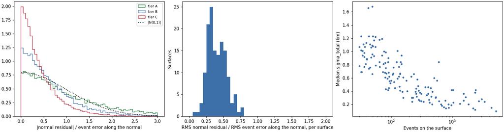

Left: member residuals normal to their surface divided by the event's catalog error along the normal. Middle: observed scatter / catalog error per surface. Right: median sigma_total against the number of events.

Per surface (1 sigma normal to the surface, median over vertices): sigma_total 0.59 km (10th-90th percentile 0.23-1.07), of which location Monte Carlo 0.46, bootstrap 0.21 and model choice 0.16 km. The location term uses the catalog errors, which for tiers B and C are larger than the scatter, so it is an upper bound. It treats errors as independent between events; errors shared by nearby events (velocity model, station terms) move a whole surface and are not in it; the v0 → v1 shift of matched surfaces (median 5.9 km horizontally) shows their size between two location runs. Strike and dip: bootstrap 68 % interval widths, median 2.0° and 3.1°; with the location Monte Carlo 5.7° and 7.0°. Centroid: 0.72 km horizontally and 0.31 km in depth (bootstrap). 49 of 142 surfaces are stable (median Jaccard ≥ 0.5 over the four detection reruns; v0: 50 of 141).

**These sigmas and intervals hold for a fixed set of members.** They do not include the choice of members made by the detection, which dominates: over the four detection reruns the strike of the best-matching plane ranges over a median 103° (dip 22°) for the 84 unstable surfaces and 6.5° (dip 8.0°) for the 42 stable ones (non-strand surfaces matched in at least one rerun; the 12 strands are not rerun, and v1_MT031, v1_ON025, v1_WA002, v1_WA004 match no plane in any rerun). Recovery of the 130 non-strand surfaces in the verifier's detection reruns (strands are made by a separate map-view search that these reruns do not repeat):

| test | description | surfaces_tested | recovered | recovered_of_stable | median_jaccard |
| --- | --- | --- | --- | --- | --- |
| sub80 | random 80 % of the fit set | 130 | 38 | 27/42 | 0.31 |
| perturbed | every event moved once by its own error | 130 | 12 | 9/42 | 0.20 |
| tierAB | tiers A-B only | 116 | 10 | 6/33 | 0.08 |

Per tier, member residuals against catalog errors (expected values without and with the truncation by the selection tolerance):

| tier | members | median_abs_resid_over_sigma | expected_untruncated | expected_with_truncation | median_sigma_n_km | rms_resid_km |
| --- | --- | --- | --- | --- | --- | --- |
| A | 11899 | 0.77 | 0.67 | 0.67 | 0.89 | 1.25 |
| B | 15336 | 0.49 | 0.67 | 0.60 | 1.47 | 1.23 |
| C | 37037 | 0.30 | 0.67 | 0.42 | 2.19 | 1.12 |

## Checks and limits

- 14 surfaces have mesh vertices above the ground or seafloor (GMT earth_relief 01m): the rectangle is extrapolated 0.5 km and to the 2-98 % extent of the members; no hypocentre is above the surface (catalog v5.1). Listed in the summary (n_vertices_above_surface).
- 37 surfaces have fewer than half of their events with depth_quality ok (Blanco outside the 2012-13 OBS deployment, Gorda far from stations): their dips and depth extents rest on poorly constrained depths; dip_depth_ok and events_depth_ok_2pct_km/98pct_km give the same from the ok events only.
- Rectangles are crude: one plane or gentle quadratic over the 2-98 % extent of the members. Curved or branching faults come out as several rectangles.
- No relative relocation: the scatter about the surfaces (RMS about 1.2 km) is still wider than double-difference catalogs show for the same faults.
- ComCat focal mechanisms were not used to steer or check the surfaces (PI rule).
- The mesh vertex elevations (surface_elev_km) use GMT earth_relief 01m, not the merged GMRT surface of the catalog.

## Proposed decisions

1. Dip rule in every reassignment pass (v1_detect.reassign_dip): a plane flatter than 30° after reassignment is dropped and its events go back to the other planes. v0 checked the dip only at detection and merging; 24 of its 141 surfaces ended flatter. Effect on v5.1: 192 → 161 planes, 74 % → 67 % of the fit set on a plane. Cost: by design, faults flatter than 30° cannot be represented. Of v0's 24 surfaces flatter than 30°: 7 merged, 6 matched, 4 dispersed, 3 split and merged, 3 lost, 1 split. Among them, MT010 (12°, 774 events, medium-high confidence: 1992 Mw 7.2 Cape Mendocino / 1991 M6.0 Honeydew low-angle thrust zone) is dispersed over v1_MT007 16%, v1_MT001 15%, v1_MT003 14%; PU016 (21°, 79 events, medium confidence: Olympia structure, SE end) is lost; PU021 (20°, 62 events, low confidence: Shallow LRF / Langford area) is lost. A low-angle thrust such as the 1992 Cape Mendocino / Honeydew zone needs another method (for example a fit without the dip rule restricted to that zone).
2. Event selection: 'deep-pass-only' read as deep_pass = True (83 tier A-C events); anss_other_event and anss_sonic_boom also excluded as non-earthquakes (1 event); Axial left out as in v0; the 2 loc_source comcat rows (tier U) are assigned with nominal errors of 1.5 km (horizontal) and 3 km (depth).
3. Per-event error: sigma_h = sqrt((h_min² + h_max²)/2) / 1.515, isotropic (no ellipse azimuth in the catalog); sigma_z = sig_z.
4. Blanco strands made automatic: parents are steep Blanco planes within 35° of 111° with under half of their events in the Cascadia Depression box (-128.82 to -128.60 E, 43.74 to 43.88 N); events in that box are kept out of the strand pools; per-year Ashman D test (2 merges); pairs merged when their depth-ok median depths would need a single fault dipping ≥ 60° (8 merges; v0 merged two such pairs by judgement).
5. Screening: surfaces with ≥ 60 % of events on weekdays 08-17 local time removed (9, 1,137 events; their 884 weekday-daytime events are marked as likely non-earthquakes and never assigned, the others are assigned like any event); Blanco surfaces centred deeper than 25 km with < 30 depth-ok events removed as deep artefacts (1). Kept surfaces with at least twice the fit-set weekday-daytime rate are flagged, with the binomial p. The 60 % cut is a judgement; all 9 removed surfaces have binomial p ≤ 3e-7 against the fit-set rate.
6. Assignment: compatible when z = d / sqrt(s_e² + s_s² + W²) ≤ 2 and d ≤ 10 km; assigned only when exactly one surface is compatible, otherwise 'ambiguous' with the two nearest listed. Without the 10 km cap and the uniqueness condition, events with errors of 10-15 km were 'compatible' with surfaces up to 70 km away. 'assigned' means compatible with one surface, not located on it; `on_surface_strict` (fit members and assigned tier A-C events within 2 km, without floor_limited, far_only or deep_pass) is the default for counting events on faults. Axial events are 'not fitted'.
7. v0 comparison: link when ≥ 15 shared fit members that are ≥ 50 % of either side, or ≥ 30 % of both; literature carried unchanged only for matched surfaces with normals within 25°, centroids within 10 km horizontally and within 5 km in depth; all other carried matches marked 're-check'.
8. Flags for catalog problems on the surfaces (summary, rectangles and mesh): Mount St Helens deep population (centroid in the review box and deeper than 20 km, or ≥ 25 % of members deeper than 30 km), 2012 Brookings swarm, members moved > 10 km in depth from v4 to v5.1, weekday-daytime excess, strand dips set by the band selection, detection-level recovery.
9. Surface IDs: v1_<region><nnn> (v0 region boxes, numbered by size); removed surfaces v1x_nn.
10. Not done here, proposed as next steps (on catalog v6.0, which will supersede v5.1): a null test of the detection (the same detection on a spatially randomised catalog of the same density, to count the 30-event 'planes' density alone gives); a fit restricted to the Cascadia Depression; a check of v1_BL009/v1_BL015 against the OBS-era depths; a separate treatment of low-angle zones. The Mount St Helens deep events and the Brookings swarm depth are now in the v5.1 review (P1, P2).

## Files

In the worktree, `data/catalog_v5/v5.1_analysis/faults/`: `fault_surfaces_v1_summary.csv` (parameters, flags, carried literature), `_uncertainty.csv`, `_rectangles.geojson` (four corners per surface), `_members.csv` (fit members), `_assignment.csv.gz` (every located event), `_assignment_by_region.csv`, `_selection.csv`, `_removed.csv` and `_removed_members.csv`, `_strand_separation.csv`, `_strand_merges.csv`, `_traces.csv`, `_v0_pairs.csv` (every linked v0-v1 pair), `_v0_status.csv` (every v0 surface), `_v0_comparison.csv` (every v1 surface, with literature), `_literature_todo.csv` (new surfaces), the PNG figures and this report. On /wd1/mdenolle_data/catalog_v5/v5.1_analysis/faults/: `fault_surfaces_v1.geojson` (1 km triangle mesh, CRESCENT CFM layout), `_vertices.csv.gz` (per-vertex sigmas), `_ensemble.csv.gz` (100 draws per vertex), `_assignment.csv.gz`, work/ (detection runs, logs, member residuals; `work/verifier_reruns/`: the verifier's three detection reruns used for the recovery columns) and RESUME.md. New columns after review: summary `strike_settings_range_width`, `dip_settings_range_width`, `recovery_J_sub80`, `recovery_J_perturbed`, `recovery_J_tierAB`, `recovery_tests`, `median_shift_z_depth_ok_km`, `weekday_daytime_p`; assignment `on_surface_strict`, `weekday_daytime`, `removed_surface`, `catalog_note`.